# Logistic Regression with Equity Analysis

CPLN 5080 - Spring 2026

Author

Published

April 8, 2026

## About This Exercise

In this exercise, you will build a model to predict recidivism

## Learning Objectives

By the end of this exercise, you will be able to:

1. Build a logistic model
2. Evaluate model performance
   - Assess sensitivity, precision, and specificity
   - Select an appropriate threshold
3. Discuss the consequences of threshold selection
4. Discuss whether the model is ready to be deployed

## SET UP

```r
# Load required packages
library(tidyverse)   # For data manipulation and visualization
library(caret)       # For model training and confusion matrices
library(pROC)        # For ROC curves and AUC
library(here)

# Set random seed for reproducibility
set.seed(2025)

# Configure visualization theme
theme_set(theme_minimal())
```

## LOAD AND EXPLORE DATA

```r
# Load Georgia Department of Corrections recidivism data
# Source: National Institute of Justice Recidivism Challenge
recidivism_data <- read_csv(here("data/NIJ_s_Recidivism_Challenge_Full_Dataset_20240407.csv"))
# Examine data structure
glimpse(recidivism_data)
```

```
Rows: 25,835
Columns: 54
$ ID                                                <dbl> 1, 2, 3, 4, 5, 6, 7,…
$ Gender                                            <chr> "M", "M", "M", "M", …
$ Race                                              <chr> "BLACK", "BLACK", "B…
$ Age_at_Release                                    <chr> "43-47", "33-37", "4…
$ Residence_PUMA                                    <dbl> 16, 16, 24, 16, 16, …
$ Gang_Affiliated                                   <lgl> FALSE, FALSE, FALSE,…
$ Supervision_Risk_Score_First                      <dbl> 3, 6, 7, 7, 4, 5, 2,…
$ Supervision_Level_First                           <chr> "Standard", "Special…
$ Education_Level                                   <chr> "At least some colle…
$ Dependents                                        <chr> "3 or more", "1", "3…
$ Prison_Offense                                    <chr> "Drug", "Violent/Non…
$ Prison_Years                                      <chr> "More than 3 years",…
$ Prior_Arrest_Episodes_Felony                      <chr> "6", "7", "6", "8", …
```

[output cut: 41 more lines]

```r
# Check outcome variable distribution
table(recidivism_data$Recidivism_Within_3years, useNA = "ifany")
```

```
FALSE  TRUE
10931 14904
```

```r
# Calculate overall recidivism rate
mean(recidivism_data$Recidivism_Within_3years, na.rm = TRUE)
```

```
[1] 0.5768918
```

```r
# Examine recidivism rates by race
recidivism_data %>%
  filter(!is.na(Race), !is.na(Recidivism_Within_3years)) %>%
  group_by(Race) %>%
  summarise(
    n = n(),
    recidivism_rate = mean(Recidivism_Within_3years),
    avg_age = mean(Age_at_Release, na.rm = TRUE),
    avg_prior_felonies = mean(Prior_Arrest_Episodes_Felony, na.rm = TRUE)
  ) %>%
  arrange(desc(recidivism_rate))
```

```
# A tibble: 2 × 5
  Race      n recidivism_rate avg_age avg_prior_felonies
  <chr> <int>           <dbl>   <dbl>              <dbl>
1 BLACK 14847           0.587      NA                 NA
2 WHITE 10988           0.563      NA                 NA
```

# Critical pause:

- Why do base rates differ across groups? Consider both individual factors and systemic factors (differential policing, economic opportunities, program access, etc.)

## CLEAN DATA

```r
# Clean and prepare data for modeling
model_data <- recidivism_data %>%
  # Create binary outcome variable (must be numeric for glm)
  mutate(recidivism = as.integer(Recidivism_Within_3years == TRUE)) %>%
  # Select relevant features
  select(
    recidivism,                         # Outcome
    Age_at_Release,                     # Demographics
    Gender,
    Race,
    Gang_Affiliated,                    # Risk factors
    Dependents,
    Prior_Arrest_Episodes_Felony,       # Criminal history
    Prior_Arrest_Episodes_Violent,
    Prior_Conviction_Episodes_Prop,
    Condition_MH_SA,                    # Mental health / substance abuse
    Supervision_Risk_Score_First,       # Official risk score
    Percent_Days_Employed,              # Economic factors
    Education_Level                     # Education
  ) %>%
  # Remove missing values (in practice, consider imputation)
  na.omit()

# Check final sample characteristics
cat("Final sample size:", nrow(model_data), "individuals\n")
```

```
Final sample size: 21837 individuals
```

```r
cat("Recidivism rate:", round(mean(model_data$recidivism), 3), "\n\n")
```

```
Recidivism rate: 0.604
```

```r
# Sample size by race
model_data %>%
  count(Race) %>%
  arrange(desc(n))
```

```
# A tibble: 2 × 2
  Race      n
  <chr> <int>
1 BLACK 13220
2 WHITE  8617
```

## CREATE TRAINING AND TESTING DATA

```r
# Create stratified train-test split (maintains outcome distribution)
trainIndex <- createDataPartition(
  y = model_data$recidivism,
  p = 0.70,           # 70% training, 30% testing
  list = FALSE
)

train_data <- model_data[trainIndex, ]
test_data <- model_data[-trainIndex, ]

# Verify split preserves outcome distribution
cat("Training set:\n")
```

```
Training set:
```

```r
cat("  N =", nrow(train_data), "\n")
```

```
  N = 15286
```

```r
cat("  Recidivism rate =", round(mean(train_data$recidivism), 3), "\n\n")
```

```
  Recidivism rate = 0.606
```

```r
cat("Test set:\n")
```

```
Test set:
```

```r
cat("  N =", nrow(test_data), "\n")
```

```
  N = 6551
```

```r
cat("  Recidivism rate =", round(mean(test_data$recidivism), 3), "\n\n")
```

```
  Recidivism rate = 0.599
```

## TRAIN MODEL

```r
# Fit logistic regression model
# Note: We're excluding Race from predictors to avoid direct discrimination,
# but this doesn't eliminate bias (proxy variables may exist)
logit_model <- glm(
  recidivism ~ Age_at_Release +
               Dependents +
               Gang_Affiliated +
               Prior_Arrest_Episodes_Felony +
               Prior_Arrest_Episodes_Violent +
               Prior_Conviction_Episodes_Prop +
               Percent_Days_Employed +
               Supervision_Risk_Score_First,
  data = train_data,
  family = "binomial"  # Specifies logistic regression
)

# View model summary
summary(logit_model)
```

```
Call:
glm(formula = recidivism ~ Age_at_Release + Dependents + Gang_Affiliated +
    Prior_Arrest_Episodes_Felony + Prior_Arrest_Episodes_Violent +
    Prior_Conviction_Episodes_Prop + Percent_Days_Employed +
    Supervision_Risk_Score_First, family = "binomial", data = train_data)

Coefficients:
                                         Estimate Std. Error z value Pr(>|z|)
(Intercept)                              1.536623   0.205913   7.462 8.49e-14
Age_at_Release23-27                     -0.306180   0.078571  -3.897 9.75e-05
Age_at_Release28-32                     -0.626801   0.082161  -7.629 2.37e-14
Age_at_Release33-37                     -0.884262   0.087578 -10.097  < 2e-16
Age_at_Release38-42                     -1.097585   0.095083 -11.543  < 2e-16
Age_at_Release43-47                     -1.328051   0.099313 -13.372  < 2e-16
Age_at_Release48 or older               -1.774217   0.098409 -18.029  < 2e-16
Dependents1                              0.112010   0.051801   2.162 0.030593
Dependents2                              0.118375   0.055002   2.152 0.031382
Dependents3 or more                     -0.022584   0.047740  -0.473 0.636171
Gang_AffiliatedTRUE                      0.760899   0.057000  13.349  < 2e-16
Prior_Arrest_Episodes_Felony1           -1.262064   0.197966  -6.375 1.83e-10
Prior_Arrest_Episodes_Felony10 or more   0.484253   0.197974   2.446 0.014444
Prior_Arrest_Episodes_Felony2           -0.723727   0.196190  -3.689 0.000225
Prior_Arrest_Episodes_Felony3           -0.513387   0.196169  -2.617 0.008869
Prior_Arrest_Episodes_Felony4           -0.320167   0.196595  -1.629 0.103406
Prior_Arrest_Episodes_Felony5           -0.201793   0.197509  -1.022 0.306928
Prior_Arrest_Episodes_Felony6           -0.061271   0.199735  -0.307 0.759025
Prior_Arrest_Episodes_Felony7           -0.180865   0.201464  -0.898 0.369318
Prior_Arrest_Episodes_Felony8            0.046340   0.205038   0.226 0.821197
Prior_Arrest_Episodes_Felony9            0.137792   0.209034   0.659 0.509777
Prior_Arrest_Episodes_Violent1           0.070370   0.044557   1.579 0.114264
Prior_Arrest_Episodes_Violent2           0.109302   0.056685   1.928 0.053827
Prior_Arrest_Episodes_Violent3 or more   0.167071   0.058030   2.879 0.003989
Prior_Conviction_Episodes_Prop1          0.144881   0.047901   3.025 0.002490
Prior_Conviction_Episodes_Prop2          0.230322   0.061184   3.764 0.000167
Prior_Conviction_Episodes_Prop3 or more  0.431137   0.061050   7.062 1.64e-12
Percent_Days_Employed                   -1.124559   0.043608 -25.788  < 2e-16
Supervision_Risk_Score_First             0.022286   0.009194   2.424 0.015352

(Intercept)                             ***
Age_at_Release23-27                     ***
```

[output cut: 22 more lines]

```
Prior_Conviction_Episodes_Prop1         **
Prior_Conviction_Episodes_Prop2         ***
Prior_Conviction_Episodes_Prop3 or more ***
Percent_Days_Employed                   ***
Supervision_Risk_Score_First            *
---
Signif. codes:  0 '***' 0.001 '**' 0.01 '*' 0.05 '.' 0.1 ' ' 1

(Dispersion parameter for binomial family taken to be 1)

    Null deviance: 20500  on 15285  degrees of freedom
Residual deviance: 17780  on 15257  degrees of freedom
AIC: 17838

Number of Fisher Scoring iterations: 4
```

```r
# Interpret coefficients as odds ratios
exp(coef(logit_model))
```

```
                            (Intercept)                     Age_at_Release23-27
                              4.6488629                               0.7362542
                    Age_at_Release28-32                     Age_at_Release33-37
                              0.5342983                               0.4130187
                    Age_at_Release38-42                     Age_at_Release43-47
                              0.3336758                               0.2649933
              Age_at_Release48 or older                             Dependents1
                              0.1696161                               1.1185242
                            Dependents2                     Dependents3 or more
                              1.1256661                               0.9776691
                    Gang_AffiliatedTRUE           Prior_Arrest_Episodes_Felony1
                              2.1401994                               0.2830692
 Prior_Arrest_Episodes_Felony10 or more           Prior_Arrest_Episodes_Felony2
                              1.6229618                               0.4849416
          Prior_Arrest_Episodes_Felony3           Prior_Arrest_Episodes_Felony4
                              0.5984653                               0.7260279
          Prior_Arrest_Episodes_Felony5           Prior_Arrest_Episodes_Felony6
                              0.8172644                               0.9405683
          Prior_Arrest_Episodes_Felony7           Prior_Arrest_Episodes_Felony8
                              0.8345479                               1.0474303
          Prior_Arrest_Episodes_Felony9          Prior_Arrest_Episodes_Violent1
                              1.1477367                               1.0729050
         Prior_Arrest_Episodes_Violent2  Prior_Arrest_Episodes_Violent3 or more
                              1.1154991                               1.1818388
        Prior_Conviction_Episodes_Prop1         Prior_Conviction_Episodes_Prop2
                              1.1559020                               1.2590059
Prior_Conviction_Episodes_Prop3 or more                   Percent_Days_Employed
                              1.5390061                               0.3247958
           Supervision_Risk_Score_First
                              1.0225361
```

# Interpretation note:

Coefficients show log-odds relationship - Odds ratios > 1 indicate increased risk - Odds ratios < 1 indicate decreased risk

##PREDICT

```r
# Generate predicted probabilities on test set
test_data <- test_data %>%
  mutate(
    predicted_prob = predict(logit_model, newdata = test_data, type = "response")
  )

# Examine distribution of predicted probabilities
summary(test_data$predicted_prob)
```

```
   Min. 1st Qu.  Median    Mean 3rd Qu.    Max.
0.07046 0.45871 0.63226 0.60528 0.76880 0.96374
```

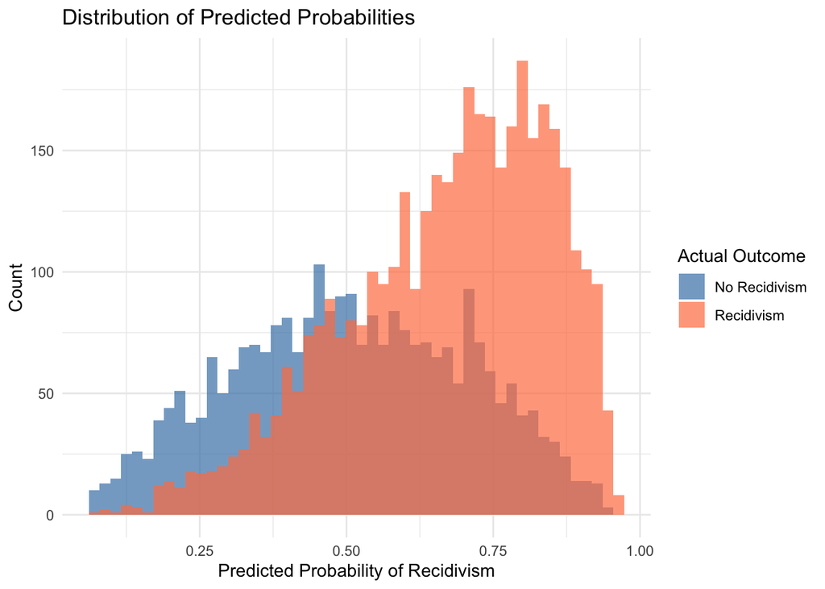

```r
# Visualize predicted probabilities by actual outcome
ggplot(test_data, aes(x = predicted_prob, fill = as.factor(recidivism))) +
  geom_histogram(bins = 50, alpha = 0.7, position = "identity") +
  scale_fill_manual(
    values = c("steelblue", "coral"),
    labels = c("No Recidivism", "Recidivism")
  ) +
  labs(
    title = "Distribution of Predicted Probabilities",
    x = "Predicted Probability of Recidivism",
    y = "Count",
    fill = "Actual Outcome"
  )
```

##EVALUATE PREDICTIONS

#Confusion matrix at default threshold 0.5

```r
test_data <- test_data %>%
  mutate(predicted_class_50 = ifelse(predicted_prob > 0.5, 1, 0))

# Create confusion matrix
cm_50 <- confusionMatrix(
  as.factor(test_data$predicted_class_50),
  as.factor(test_data$recidivism),
  positive = "1"  # "1" is the positive class (recidivism)
)

print(cm_50)
```

```
Confusion Matrix and Statistics

          Reference
Prediction    0    1
         0 1294  719
         1 1334 3204

               Accuracy : 0.6866
                 95% CI : (0.6752, 0.6978)
    No Information Rate : 0.5988
    P-Value [Acc > NIR] : < 2.2e-16

                  Kappa : 0.3215

 Mcnemar's Test P-Value : < 2.2e-16

            Sensitivity : 0.8167
            Specificity : 0.4924
         Pos Pred Value : 0.7060
         Neg Pred Value : 0.6428
             Prevalence : 0.5988
         Detection Rate : 0.4891
   Detection Prevalence : 0.6927
      Balanced Accuracy : 0.6546

       'Positive' Class : 1
```

```r
# Extract key metrics
cat("\nKey Metrics at Threshold = 0.5:\n")
```

```
Key Metrics at Threshold = 0.5:
```

```r
cat("Sensitivity (Recall):", round(cm_50$byClass["Sensitivity"], 3),
    "- Proportion of actual recidivists correctly identified\n")
```

```
Sensitivity (Recall): 0.817 - Proportion of actual recidivists correctly identified
```

```r
cat("Specificity:", round(cm_50$byClass["Specificity"], 3),
    "- Proportion of non-recidivists correctly identified\n")
```

```
Specificity: 0.492 - Proportion of non-recidivists correctly identified
```

```r
cat("Precision (PPV):", round(cm_50$byClass["Precision"], 3),
    "- Proportion of predicted recidivists who actually recidivated\n")
```

```
Precision (PPV): 0.706 - Proportion of predicted recidivists who actually recidivated
```

```r
cat("Accuracy:", round(cm_50$overall["Accuracy"], 3), "\n\n")
```

```
Accuracy: 0.687
```

#ROC Curve and AUC

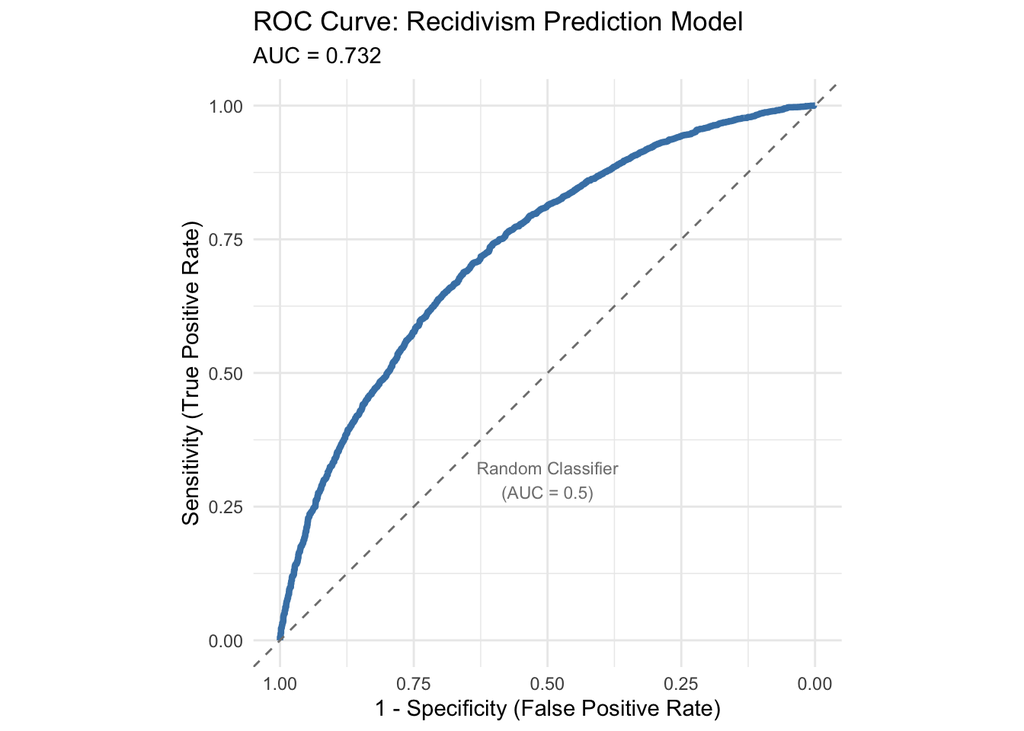

```r
# Generate ROC curve
roc_obj <- roc(
  response = test_data$recidivism,
  predictor = test_data$predicted_prob
)

# Plot ROC curve
ggroc(roc_obj, color = "steelblue", size = 1.5) +
  geom_abline(slope = 1, intercept = 1, linetype = "dashed", color = "gray50") +
  labs(
    title = "ROC Curve: Recidivism Prediction Model",
    subtitle = paste0("AUC = ", round(auc(roc_obj), 3)),
    x = "1 - Specificity (False Positive Rate)",
    y = "Sensitivity (True Positive Rate)"
  ) +
  annotate("text", x = 0.5, y = 0.3,
           label = "Random Classifier\n(AUC = 0.5)",
           color = "gray50", size = 3) +
  coord_fixed()
```

```r
# Print AUC
cat("Area Under the Curve (AUC):", round(auc(roc_obj), 3), "\n")
```

```
Area Under the Curve (AUC): 0.732
```

```r
cat("Interpretation: AUC of", round(auc(roc_obj), 2),
    "indicates", ifelse(auc(roc_obj) > 0.8, "good", "acceptable"),
    "discrimination\n\n")
```

```
Interpretation: AUC of 0.73 indicates acceptable discrimination
```

#Test threshold performance

```r
# Test three different thresholds
thresholds_to_test <- c(0.3, 0.5, 0.7)

threshold_results <- map_df(thresholds_to_test, function(thresh) {
  # Generate predictions at this threshold
  preds <- ifelse(test_data$predicted_prob > thresh, 1, 0)

  # Calculate confusion matrix
  cm <- confusionMatrix(
    as.factor(preds),
    as.factor(test_data$recidivism),
    positive = "1"
  )

  # Extract metrics
  data.frame(
    threshold = thresh,
    accuracy = cm$overall["Accuracy"],
    sensitivity = cm$byClass["Sensitivity"],
    specificity = cm$byClass["Specificity"],
    precision = cm$byClass["Precision"],
    f1_score = cm$byClass["F1"],
    # Calculate false positive and false negative rates
    fpr = 1 - cm$byClass["Specificity"],
    fnr = 1 - cm$byClass["Sensitivity"]
  )
})

# Display results
print(threshold_results)
```

```
             threshold  accuracy sensitivity specificity precision  f1_score
Accuracy...1       0.3 0.6476874   0.9686464   0.1685693 0.6349206 0.7670569
Accuracy...2       0.5 0.6866127   0.8167219   0.4923896 0.7060379 0.7573573
Accuracy...3       0.7 0.6209739   0.5034412   0.7964231 0.7868526 0.6140215
                   fpr        fnr
Accuracy...1 0.8314307 0.03135356
Accuracy...2 0.5076104 0.18327810
Accuracy...3 0.2035769 0.49655876
```

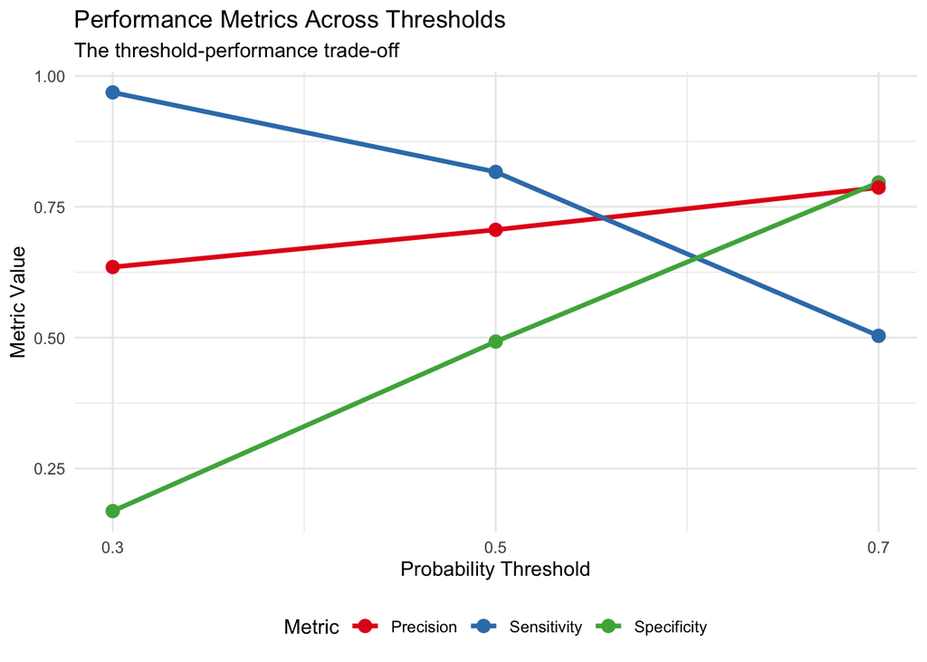

```r
# Visualize threshold trade-offs
threshold_results %>%
  select(threshold, sensitivity, specificity, precision) %>%
  pivot_longer(cols = c(sensitivity, specificity, precision),
               names_to = "metric",
               values_to = "value") %>%
  ggplot(aes(x = threshold, y = value, color = metric, group = metric)) +
  geom_line(size = 1.2) +
  geom_point(size = 3) +
  scale_color_brewer(palette = "Set1",
                     labels = c("Precision", "Sensitivity", "Specificity")) +
  scale_x_continuous(breaks = thresholds_to_test) +
  labs(
    title = "Performance Metrics Across Thresholds",
    subtitle = "The threshold-performance trade-off",
    x = "Probability Threshold",
    y = "Metric Value",
    color = "Metric"
  ) +
  theme(legend.position = "bottom")
```

# CRITICAL INSIGHT: As threshold increases:

- Fewer people flagged as high-risk (more conservative)
- Sensitivity decreases (miss more actual recidivists)
- Specificity increases (fewer false accusations)
- Precision usually increases (predictions more accurate when made)

##EQUITY ANALYSIS

# Calculate performance metrics by race

```r
# This is the most important section for policy analysis!

# First, calculate overall metrics for comparison
overall_metrics <- test_data %>%
  summarise(
    Group = "Overall",
    N = n(),
    Base_Rate = mean(recidivism),
    Sensitivity = sum(predicted_class_50 == 1 & recidivism == 1) / sum(recidivism == 1),
    Specificity = sum(predicted_class_50 == 0 & recidivism == 0) / sum(recidivism == 0),
    Precision = sum(predicted_class_50 == 1 & recidivism == 1) / sum(predicted_class_50 == 1),
    FPR = sum(predicted_class_50 == 1 & recidivism == 0) / sum(recidivism == 0),
    FNR = sum(predicted_class_50 == 0 & recidivism == 1) / sum(recidivism == 1)
  )

# Calculate metrics by race
race_metrics <- test_data %>%
  group_by(Race) %>%
  summarise(
    N = n(),
    Base_Rate = mean(recidivism),
    Sensitivity = sum(predicted_class_50 == 1 & recidivism == 1) / sum(recidivism == 1),
    Specificity = sum(predicted_class_50 == 0 & recidivism == 0) / sum(recidivism == 0),
    Precision = sum(predicted_class_50 == 1 & recidivism == 1) / sum(predicted_class_50 == 1),
    FPR = sum(predicted_class_50 == 1 & recidivism == 0) / sum(recidivism == 0),
    FNR = sum(predicted_class_50 == 0 & recidivism == 1) / sum(recidivism == 1)
  ) %>%
  rename(Group = Race)

# Combine overall and by-group metrics
equity_analysis <- bind_rows(overall_metrics, race_metrics)

# Display results
print("=" %>% rep(80) %>% paste0(collapse = ""))
```

```
[1] "================================================================================"
```

```r
print("EQUITY ANALYSIS: Model Performance by Race (Threshold = 0.5)")
```

```
[1] "EQUITY ANALYSIS: Model Performance by Race (Threshold = 0.5)"
```

```r
print("=" %>% rep(80) %>% paste0(collapse = ""))
```

```
[1] "================================================================================"
```

```r
print(equity_analysis, width = Inf)
```

```
# A tibble: 3 × 8
  Group       N Base_Rate Sensitivity Specificity Precision   FPR   FNR
  <chr>   <int>     <dbl>       <dbl>       <dbl>     <dbl> <dbl> <dbl>
1 Overall  6551     0.599       0.817       0.492     0.706 0.508 0.183
2 BLACK    3931     0.598       0.846       0.438     0.691 0.562 0.154
3 WHITE    2620     0.600       0.773       0.575     0.732 0.425 0.227
```

```r
print("=" %>% rep(80) %>% paste0(collapse = ""))
```

```
[1] "================================================================================"
```

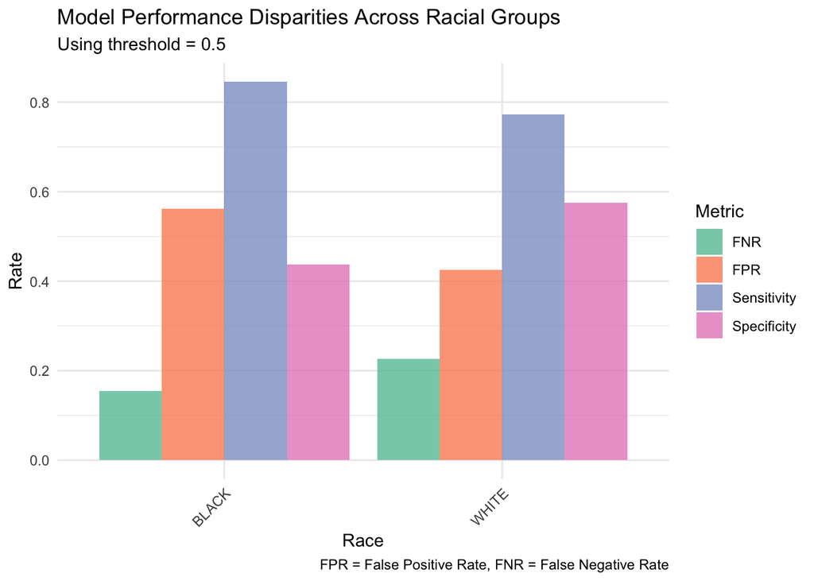

```r
# Create bar chart comparing key metrics across groups
race_metrics %>%
  select(Group, FPR, FNR, Sensitivity, Specificity) %>%
  pivot_longer(cols = c(FPR, FNR, Sensitivity, Specificity),
               names_to = "Metric",
               values_to = "Rate") %>%
  ggplot(aes(x = Group, y = Rate, fill = Metric)) +
  geom_col(position = "dodge", alpha = 0.8) +
  scale_fill_brewer(palette = "Set2") +
  labs(
    title = "Model Performance Disparities Across Racial Groups",
    subtitle = "Using threshold = 0.5",
    x = "Race",
    y = "Rate",
    fill = "Metric",
    caption = "FPR = False Positive Rate, FNR = False Negative Rate"
  ) +
  theme(axis.text.x = element_text(angle = 45, hjust = 1))
```